# Risk Factor Analysis

## Outcome Variable

**Outcome Variable:** sstunted

## Predictor Variables

**Intervention Variable:** impsan

**Adjustment Set:**

unadjusted

## Stratifying Variables

The analysis was stratified on these variable(s):

- agecat
- studyid
- country

## Data Summary

| agecat | studyid | country | impsan | sstunted | n_cell | n | outcome_variable |
| --- | --- | --- | --- | --- | --- | --- | --- |
| Birth | ki0047075b-MAL-ED | BANGLADESH | 1 | 0 | 174 | 213 | sstunted |
| Birth | ki0047075b-MAL-ED | BANGLADESH | 1 | 1 | 5 | 213 | sstunted |
| Birth | ki0047075b-MAL-ED | BANGLADESH | 0 | 0 | 33 | 213 | sstunted |
| Birth | ki0047075b-MAL-ED | BANGLADESH | 0 | 1 | 1 | 213 | sstunted |
| Birth | ki0047075b-MAL-ED | BRAZIL | 1 | 0 | 56 | 60 | sstunted |
| Birth | ki0047075b-MAL-ED | BRAZIL | 1 | 1 | 3 | 60 | sstunted |
| Birth | ki0047075b-MAL-ED | BRAZIL | 0 | 0 | 1 | 60 | sstunted |
| Birth | ki0047075b-MAL-ED | BRAZIL | 0 | 1 | 0 | 60 | sstunted |
| Birth | ki0047075b-MAL-ED | INDIA | 1 | 0 | 14 | 40 | sstunted |
| Birth | ki0047075b-MAL-ED | INDIA | 1 | 1 | 1 | 40 | sstunted |
| Birth | ki0047075b-MAL-ED | INDIA | 0 | 0 | 25 | 40 | sstunted |
| Birth | ki0047075b-MAL-ED | INDIA | 0 | 1 | 0 | 40 | sstunted |
| Birth | ki0047075b-MAL-ED | NEPAL | 1 | 0 | 24 | 26 | sstunted |
| Birth | ki0047075b-MAL-ED | NEPAL | 1 | 1 | 1 | 26 | sstunted |
| Birth | ki0047075b-MAL-ED | NEPAL | 0 | 0 | 1 | 26 | sstunted |
| Birth | ki0047075b-MAL-ED | NEPAL | 0 | 1 | 0 | 26 | sstunted |
| Birth | ki0047075b-MAL-ED | PERU | 1 | 0 | 50 | 208 | sstunted |
| Birth | ki0047075b-MAL-ED | PERU | 1 | 1 | 2 | 208 | sstunted |
| Birth | ki0047075b-MAL-ED | PERU | 0 | 0 | 154 | 208 | sstunted |
| Birth | ki0047075b-MAL-ED | PERU | 0 | 1 | 2 | 208 | sstunted |
| Birth | ki0047075b-MAL-ED | SOUTH AFRICA | 1 | 0 | 0 | 95 | sstunted |
| Birth | ki0047075b-MAL-ED | SOUTH AFRICA | 1 | 1 | 0 | 95 | sstunted |
| Birth | ki0047075b-MAL-ED | SOUTH AFRICA | 0 | 0 | 94 | 95 | sstunted |
| Birth | ki0047075b-MAL-ED | SOUTH AFRICA | 0 | 1 | 1 | 95 | sstunted |
| Birth | ki0047075b-MAL-ED | TANZANIA, UNITED REPUBLIC OF | 1 | 0 | 0 | 118 | sstunted |
| Birth | ki0047075b-MAL-ED | TANZANIA, UNITED REPUBLIC OF | 1 | 1 | 0 | 118 | sstunted |
| Birth | ki0047075b-MAL-ED | TANZANIA, UNITED REPUBLIC OF | 0 | 0 | 110 | 118 | sstunted |
| Birth | ki0047075b-MAL-ED | TANZANIA, UNITED REPUBLIC OF | 0 | 1 | 8 | 118 | sstunted |
| Birth | ki1017093-NIH-Birth | BANGLADESH | 1 | 0 | 226 | 608 | sstunted |
| Birth | ki1017093-NIH-Birth | BANGLADESH | 1 | 1 | 5 | 608 | sstunted |

[output cut: 170 more lines]

The following strata were considered:

- agecat: 24 months, studyid: ki0047075b-MAL-ED, country: BANGLADESH
- agecat: 24 months, studyid: ki0047075b-MAL-ED, country: BRAZIL
- agecat: 24 months, studyid: ki0047075b-MAL-ED, country: INDIA
- agecat: 24 months, studyid: ki0047075b-MAL-ED, country: NEPAL
- agecat: 24 months, studyid: ki0047075b-MAL-ED, country: PERU
- agecat: 24 months, studyid: ki0047075b-MAL-ED, country: SOUTH AFRICA
- agecat: 24 months, studyid: ki0047075b-MAL-ED, country: TANZANIA, UNITED REPUBLIC OF
- agecat: 24 months, studyid: ki1017093-NIH-Birth, country: BANGLADESH
- agecat: 24 months, studyid: ki1017093b-PROVIDE, country: BANGLADESH
- agecat: 24 months, studyid: ki1017093c-NIH-Crypto, country: BANGLADESH
- agecat: 24 months, studyid: ki1114097-CONTENT, country: PERU
- agecat: 24 months, studyid: ki1135781-COHORTS, country: GUATEMALA
- agecat: 24 months, studyid: ki1135781-COHORTS, country: INDIA
- agecat: 24 months, studyid: ki1135781-COHORTS, country: PHILIPPINES
- agecat: 24 months, studyid: ki1148112-LCNI-5, country: MALAWI
- agecat: 24 months, studyid: kiGH5241-JiVitA-3, country: BANGLADESH
- agecat: 24 months, studyid: kiGH5241-JiVitA-4, country: BANGLADESH
- agecat: 6 months, studyid: ki0047075b-MAL-ED, country: BANGLADESH
- agecat: 6 months, studyid: ki0047075b-MAL-ED, country: BRAZIL
- agecat: 6 months, studyid: ki0047075b-MAL-ED, country: INDIA
- agecat: 6 months, studyid: ki0047075b-MAL-ED, country: NEPAL
- agecat: 6 months, studyid: ki0047075b-MAL-ED, country: PERU
- agecat: 6 months, studyid: ki0047075b-MAL-ED, country: SOUTH AFRICA
- agecat: 6 months, studyid: ki0047075b-MAL-ED, country: TANZANIA, UNITED REPUBLIC OF
- agecat: 6 months, studyid: ki1017093-NIH-Birth, country: BANGLADESH
- agecat: 6 months, studyid: ki1017093b-PROVIDE, country: BANGLADESH
- agecat: 6 months, studyid: ki1017093c-NIH-Crypto, country: BANGLADESH
- agecat: 6 months, studyid: ki1114097-CONTENT, country: PERU
- agecat: 6 months, studyid: ki1135781-COHORTS, country: GUATEMALA
- agecat: 6 months, studyid: ki1135781-COHORTS, country: INDIA
- agecat: 6 months, studyid: ki1135781-COHORTS, country: PHILIPPINES
- agecat: 6 months, studyid: ki1148112-LCNI-5, country: MALAWI
- agecat: 6 months, studyid: kiGH5241-JiVitA-3, country: BANGLADESH
- agecat: 6 months, studyid: kiGH5241-JiVitA-4, country: BANGLADESH
- agecat: Birth, studyid: ki0047075b-MAL-ED, country: BANGLADESH
- agecat: Birth, studyid: ki0047075b-MAL-ED, country: BRAZIL
- agecat: Birth, studyid: ki0047075b-MAL-ED, country: INDIA
- agecat: Birth, studyid: ki0047075b-MAL-ED, country: NEPAL
- agecat: Birth, studyid: ki0047075b-MAL-ED, country: PERU
- agecat: Birth, studyid: ki0047075b-MAL-ED, country: SOUTH AFRICA
- agecat: Birth, studyid: ki0047075b-MAL-ED, country: TANZANIA, UNITED REPUBLIC OF
- agecat: Birth, studyid: ki1017093-NIH-Birth, country: BANGLADESH
- agecat: Birth, studyid: ki1017093b-PROVIDE, country: BANGLADESH
- agecat: Birth, studyid: ki1017093c-NIH-Crypto, country: BANGLADESH
- agecat: Birth, studyid: ki1114097-CONTENT, country: PERU
- agecat: Birth, studyid: ki1135781-COHORTS, country: GUATEMALA
- agecat: Birth, studyid: ki1135781-COHORTS, country: INDIA
- agecat: Birth, studyid: ki1135781-COHORTS, country: PHILIPPINES
- agecat: Birth, studyid: kiGH5241-JiVitA-3, country: BANGLADESH
- agecat: Birth, studyid: kiGH5241-JiVitA-4, country: BANGLADESH

### Dropped Strata

Some strata were dropped due to rare outcomes:

- agecat: Birth, studyid: ki0047075b-MAL-ED, country: BANGLADESH
- agecat: Birth, studyid: ki0047075b-MAL-ED, country: BRAZIL
- agecat: Birth, studyid: ki0047075b-MAL-ED, country: INDIA
- agecat: Birth, studyid: ki0047075b-MAL-ED, country: NEPAL
- agecat: Birth, studyid: ki0047075b-MAL-ED, country: PERU
- agecat: Birth, studyid: ki0047075b-MAL-ED, country: SOUTH AFRICA
- agecat: Birth, studyid: ki0047075b-MAL-ED, country: TANZANIA, UNITED REPUBLIC OF
- agecat: Birth, studyid: ki1017093b-PROVIDE, country: BANGLADESH
- agecat: Birth, studyid: ki1017093c-NIH-Crypto, country: BANGLADESH
- agecat: Birth, studyid: ki1114097-CONTENT, country: PERU
- agecat: Birth, studyid: ki1135781-COHORTS, country: GUATEMALA
- agecat: Birth, studyid: ki1135781-COHORTS, country: PHILIPPINES
- agecat: 6 months, studyid: ki0047075b-MAL-ED, country: BANGLADESH
- agecat: 6 months, studyid: ki0047075b-MAL-ED, country: BRAZIL
- agecat: 6 months, studyid: ki0047075b-MAL-ED, country: INDIA
- agecat: 6 months, studyid: ki0047075b-MAL-ED, country: NEPAL
- agecat: 6 months, studyid: ki0047075b-MAL-ED, country: PERU
- agecat: 6 months, studyid: ki0047075b-MAL-ED, country: SOUTH AFRICA
- agecat: 6 months, studyid: ki0047075b-MAL-ED, country: TANZANIA, UNITED REPUBLIC OF
- agecat: 6 months, studyid: ki1017093b-PROVIDE, country: BANGLADESH
- agecat: 6 months, studyid: ki1114097-CONTENT, country: PERU
- agecat: 6 months, studyid: ki1135781-COHORTS, country: GUATEMALA
- agecat: 6 months, studyid: ki1135781-COHORTS, country: PHILIPPINES
- agecat: 6 months, studyid: ki1148112-LCNI-5, country: MALAWI
- agecat: 24 months, studyid: ki0047075b-MAL-ED, country: BANGLADESH
- agecat: 24 months, studyid: ki0047075b-MAL-ED, country: BRAZIL
- agecat: 24 months, studyid: ki0047075b-MAL-ED, country: NEPAL
- agecat: 24 months, studyid: ki0047075b-MAL-ED, country: PERU
- agecat: 24 months, studyid: ki0047075b-MAL-ED, country: SOUTH AFRICA
- agecat: 24 months, studyid: ki0047075b-MAL-ED, country: TANZANIA, UNITED REPUBLIC OF
- agecat: 24 months, studyid: ki1017093b-PROVIDE, country: BANGLADESH
- agecat: 24 months, studyid: ki1114097-CONTENT, country: PERU
- agecat: 24 months, studyid: ki1148112-LCNI-5, country: MALAWI

## Methods Detail

We’re interested in the causal parameters $E[Y_a]$ for all values of $a \in \mathcal{A}$. These parameters represent the mean outcome if, possibly contrary to fact, we intervened to set all units to have $A=a$. Under the randomization and positivity assumptions, these are identified by the statistical parameters $\psi_a=E_W[E_{Y|A,W}(Y|A=a,W)]$. In addition, we’re interested in the mean of $Y$, $E[Y]$ under no intervention (the observed mean). We will estimate these parameters by using SuperLearner to fit the relevant likelihood factors – $E_{Y|A,W}(Y|A=a,W)$ and $p(A=a|W)$, and then updating our likelihood fit using a joint TMLE.

For unadjusted analyses ($W=\{\}$), initial likelihoods were estimated using Lrnr_glm to estimate the simple $E(Y|A)$ and Lrnr_mean to estimate $p(A)$. For adjusted analyses, a small library containing Lrnr_glmnet, Lrnr_xgboost, and Lrnr_mean was used.

Having estimated these parameters, we will then use the delta method to estimate relative risks and attributable risks relative to a prespecified baseline level of $A$.

# Results Detail

## Results Plots

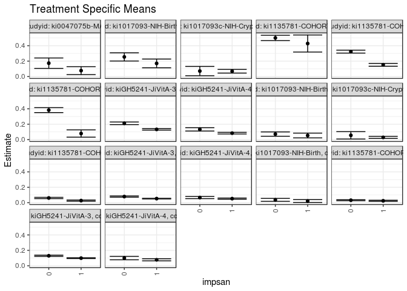

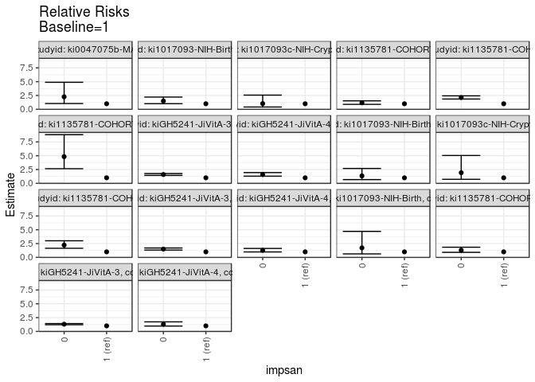

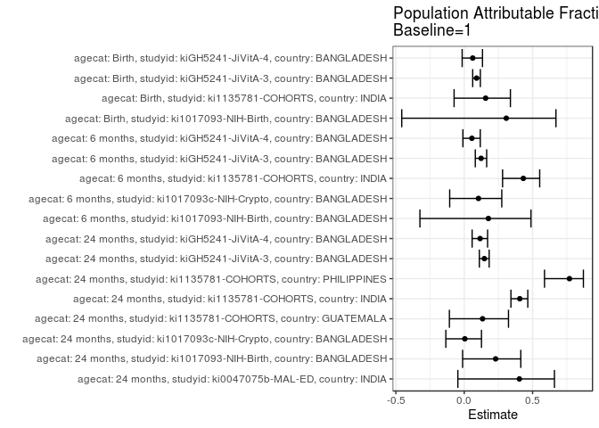

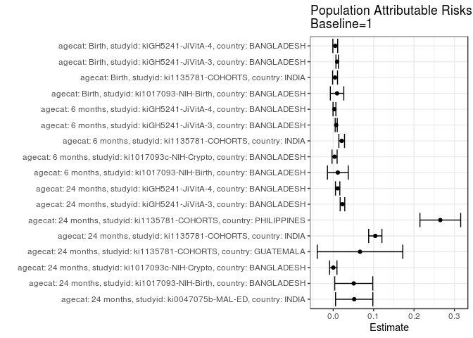

## Results Table

### Parameter: TSM

| agecat | studyid | country | intervention_level | baseline_level | estimate | ci_lower | ci_upper |
| --- | --- | --- | --- | --- | --- | --- | --- |
| Birth | ki1017093-NIH-Birth | BANGLADESH | 1 | NA | 0.0216450 | 0.0028637 | 0.0404264 |
| Birth | ki1017093-NIH-Birth | BANGLADESH | 0 | NA | 0.0371353 | 0.0180319 | 0.0562387 |
| Birth | ki1135781-COHORTS | INDIA | 1 | NA | 0.0249010 | 0.0176348 | 0.0321672 |
| Birth | ki1135781-COHORTS | INDIA | 0 | NA | 0.0322366 | 0.0259250 | 0.0385483 |
| Birth | kiGH5241-JiVitA-3 | BANGLADESH | 1 | NA | 0.0992773 | 0.0938915 | 0.1046631 |
| Birth | kiGH5241-JiVitA-3 | BANGLADESH | 0 | NA | 0.1299404 | 0.1219679 | 0.1379129 |
| Birth | kiGH5241-JiVitA-4 | BANGLADESH | 1 | NA | 0.0774874 | 0.0636609 | 0.0913139 |
| Birth | kiGH5241-JiVitA-4 | BANGLADESH | 0 | NA | 0.1001565 | 0.0778601 | 0.1224529 |
| 6 months | ki1017093-NIH-Birth | BANGLADESH | 1 | NA | 0.0536585 | 0.0227827 | 0.0845344 |
| 6 months | ki1017093-NIH-Birth | BANGLADESH | 0 | NA | 0.0722892 | 0.0444070 | 0.1001713 |
| 6 months | ki1017093c-NIH-Crypto | BANGLADESH | 1 | NA | 0.0292683 | 0.0159371 | 0.0425994 |
| 6 months | ki1017093c-NIH-Crypto | BANGLADESH | 0 | NA | 0.0561798 | 0.0083061 | 0.1040534 |
| 6 months | ki1135781-COHORTS | INDIA | 1 | NA | 0.0276449 | 0.0202349 | 0.0350549 |
| 6 months | ki1135781-COHORTS | INDIA | 0 | NA | 0.0614887 | 0.0530178 | 0.0699596 |
| 6 months | kiGH5241-JiVitA-3 | BANGLADESH | 1 | NA | 0.0531650 | 0.0489392 | 0.0573907 |
| 6 months | kiGH5241-JiVitA-3 | BANGLADESH | 0 | NA | 0.0795884 | 0.0715562 | 0.0876206 |
| 6 months | kiGH5241-JiVitA-4 | BANGLADESH | 1 | NA | 0.0530262 | 0.0453665 | 0.0606860 |
| 6 months | kiGH5241-JiVitA-4 | BANGLADESH | 0 | NA | 0.0669111 | 0.0530206 | 0.0808016 |
| 24 months | ki0047075b-MAL-ED | INDIA | 1 | NA | 0.0769231 | 0.0255961 | 0.1282501 |
| 24 months | ki0047075b-MAL-ED | INDIA | 0 | NA | 0.1735537 | 0.1059225 | 0.2411849 |
| 24 months | ki1017093-NIH-Birth | BANGLADESH | 1 | NA | 0.1705882 | 0.1139786 | 0.2271978 |
| 24 months | ki1017093-NIH-Birth | BANGLADESH | 0 | NA | 0.2548263 | 0.2016943 | 0.3079582 |
| 24 months | ki1017093c-NIH-Crypto | BANGLADESH | 1 | NA | 0.0692841 | 0.0453420 | 0.0932261 |
| 24 months | ki1017093c-NIH-Crypto | BANGLADESH | 0 | NA | 0.0714286 | 0.0110372 | 0.1318199 |
| 24 months | ki1135781-COHORTS | GUATEMALA | 1 | NA | 0.4285714 | 0.3179756 | 0.5391672 |
| 24 months | ki1135781-COHORTS | GUATEMALA | 0 | NA | 0.5012255 | 0.4669001 | 0.5355508 |
| 24 months | ki1135781-COHORTS | INDIA | 1 | NA | 0.1522774 | 0.1339143 | 0.1706404 |
| 24 months | ki1135781-COHORTS | INDIA | 0 | NA | 0.3236842 | 0.3044766 | 0.3428919 |
| 24 months | ki1135781-COHORTS | PHILIPPINES | 1 | NA | 0.0793651 | 0.0321435 | 0.1265867 |
| 24 months | ki1135781-COHORTS | PHILIPPINES | 0 | NA | 0.3831019 | 0.3506698 | 0.4155339 |
| 24 months | kiGH5241-JiVitA-3 | BANGLADESH | 1 | NA | 0.1330388 | 0.1234810 | 0.1425965 |
| 24 months | kiGH5241-JiVitA-3 | BANGLADESH | 0 | NA | 0.2118678 | 0.1947977 | 0.2289378 |
| 24 months | kiGH5241-JiVitA-4 | BANGLADESH | 1 | NA | 0.0841705 | 0.0737720 | 0.0945690 |
| 24 months | kiGH5241-JiVitA-4 | BANGLADESH | 0 | NA | 0.1334586 | 0.1118081 | 0.1551092 |

### Parameter: E(Y)

| agecat | studyid | country | intervention_level | baseline_level | estimate | ci_lower | ci_upper |
| --- | --- | --- | --- | --- | --- | --- | --- |
| Birth | ki1017093-NIH-Birth | BANGLADESH | NA | NA | 0.0312500 | 0.0174085 | 0.0450915 |
| Birth | ki1135781-COHORTS | INDIA | NA | NA | 0.0295226 | 0.0247216 | 0.0343236 |
| Birth | kiGH5241-JiVitA-3 | BANGLADESH | NA | NA | 0.1091347 | 0.1045758 | 0.1136935 |
| Birth | kiGH5241-JiVitA-4 | BANGLADESH | NA | NA | 0.0826241 | 0.0709364 | 0.0943118 |
| 6 months | ki1017093-NIH-Birth | BANGLADESH | NA | NA | 0.0651769 | 0.0442802 | 0.0860736 |
| 6 months | ki1017093c-NIH-Crypto | BANGLADESH | NA | NA | 0.0326705 | 0.0195292 | 0.0458117 |
| 6 months | ki1135781-COHORTS | INDIA | NA | NA | 0.0486824 | 0.0426994 | 0.0546654 |
| 6 months | kiGH5241-JiVitA-3 | BANGLADESH | NA | NA | 0.0606548 | 0.0567999 | 0.0645096 |
| 6 months | kiGH5241-JiVitA-4 | BANGLADESH | NA | NA | 0.0561658 | 0.0493946 | 0.0629370 |
| 24 months | ki0047075b-MAL-ED | INDIA | NA | NA | 0.1288889 | 0.0850087 | 0.1727691 |
| 24 months | ki1017093-NIH-Birth | BANGLADESH | NA | NA | 0.2214452 | 0.1821080 | 0.2607825 |
| 24 months | ki1017093c-NIH-Crypto | BANGLADESH | NA | NA | 0.0695825 | 0.0473246 | 0.0918405 |
| 24 months | ki1135781-COHORTS | GUATEMALA | NA | NA | 0.4949608 | 0.4621502 | 0.5277714 |
| 24 months | ki1135781-COHORTS | INDIA | NA | NA | 0.2564649 | 0.2424885 | 0.2704414 |
| 24 months | ki1135781-COHORTS | PHILIPPINES | NA | NA | 0.3444444 | 0.3148293 | 0.3740596 |
| 24 months | kiGH5241-JiVitA-3 | BANGLADESH | NA | NA | 0.1559963 | 0.1472522 | 0.1647404 |
| 24 months | kiGH5241-JiVitA-4 | BANGLADESH | NA | NA | 0.0952180 | 0.0856733 | 0.1047628 |

### Parameter: RR

| agecat | studyid | country | intervention_level | baseline_level | estimate | ci_lower | ci_upper |
| --- | --- | --- | --- | --- | --- | --- | --- |
| Birth | ki1017093-NIH-Birth | BANGLADESH | 1 | 1 | 1.000000 | 1.0000000 | 1.000000 |
| Birth | ki1017093-NIH-Birth | BANGLADESH | 0 | 1 | 1.715650 | 0.6256664 | 4.704511 |
| Birth | ki1135781-COHORTS | INDIA | 1 | 1 | 1.000000 | 1.0000000 | 1.000000 |
| Birth | ki1135781-COHORTS | INDIA | 0 | 1 | 1.294593 | 0.9110060 | 1.839694 |
| Birth | kiGH5241-JiVitA-3 | BANGLADESH | 1 | 1 | 1.000000 | 1.0000000 | 1.000000 |
| Birth | kiGH5241-JiVitA-3 | BANGLADESH | 0 | 1 | 1.308863 | 1.2080025 | 1.418145 |
| Birth | kiGH5241-JiVitA-4 | BANGLADESH | 1 | 1 | 1.000000 | 1.0000000 | 1.000000 |
| Birth | kiGH5241-JiVitA-4 | BANGLADESH | 0 | 1 | 1.292552 | 0.9679642 | 1.725984 |
| 6 months | ki1017093-NIH-Birth | BANGLADESH | 1 | 1 | 1.000000 | 1.0000000 | 1.000000 |
| 6 months | ki1017093-NIH-Birth | BANGLADESH | 0 | 1 | 1.347207 | 0.6738877 | 2.693278 |
| 6 months | ki1017093c-NIH-Crypto | BANGLADESH | 1 | 1 | 1.000000 | 1.0000000 | 1.000000 |
| 6 months | ki1017093c-NIH-Crypto | BANGLADESH | 0 | 1 | 1.919476 | 0.7303803 | 5.044477 |
| 6 months | ki1135781-COHORTS | INDIA | 1 | 1 | 1.000000 | 1.0000000 | 1.000000 |
| 6 months | ki1135781-COHORTS | INDIA | 0 | 1 | 2.224235 | 1.6454938 | 3.006525 |
| 6 months | kiGH5241-JiVitA-3 | BANGLADESH | 1 | 1 | 1.000000 | 1.0000000 | 1.000000 |
| 6 months | kiGH5241-JiVitA-3 | BANGLADESH | 0 | 1 | 1.497008 | 1.3183605 | 1.699864 |
| 6 months | kiGH5241-JiVitA-4 | BANGLADESH | 1 | 1 | 1.000000 | 1.0000000 | 1.000000 |
| 6 months | kiGH5241-JiVitA-4 | BANGLADESH | 0 | 1 | 1.261848 | 0.9826800 | 1.620326 |
| 24 months | ki0047075b-MAL-ED | INDIA | 1 | 1 | 1.000000 | 1.0000000 | 1.000000 |
| 24 months | ki0047075b-MAL-ED | INDIA | 0 | 1 | 2.256198 | 1.0418240 | 4.886076 |
| 24 months | ki1017093-NIH-Birth | BANGLADESH | 1 | 1 | 1.000000 | 1.0000000 | 1.000000 |
| 24 months | ki1017093-NIH-Birth | BANGLADESH | 0 | 1 | 1.493809 | 1.0094588 | 2.210556 |
| 24 months | ki1017093c-NIH-Crypto | BANGLADESH | 1 | 1 | 1.000000 | 1.0000000 | 1.000000 |
| 24 months | ki1017093c-NIH-Crypto | BANGLADESH | 0 | 1 | 1.030952 | 0.4135862 | 2.569870 |
| 24 months | ki1135781-COHORTS | GUATEMALA | 1 | 1 | 1.000000 | 1.0000000 | 1.000000 |
| 24 months | ki1135781-COHORTS | GUATEMALA | 0 | 1 | 1.169526 | 0.8954843 | 1.527432 |
| 24 months | ki1135781-COHORTS | INDIA | 1 | 1 | 1.000000 | 1.0000000 | 1.000000 |
| 24 months | ki1135781-COHORTS | INDIA | 0 | 1 | 2.125623 | 1.8583068 | 2.431392 |
| 24 months | ki1135781-COHORTS | PHILIPPINES | 1 | 1 | 1.000000 | 1.0000000 | 1.000000 |
| 24 months | ki1135781-COHORTS | PHILIPPINES | 0 | 1 | 4.827083 | 2.6465526 | 8.804183 |
| 24 months | kiGH5241-JiVitA-3 | BANGLADESH | 1 | 1 | 1.000000 | 1.0000000 | 1.000000 |
| 24 months | kiGH5241-JiVitA-3 | BANGLADESH | 0 | 1 | 1.592526 | 1.4333234 | 1.769413 |
| 24 months | kiGH5241-JiVitA-4 | BANGLADESH | 1 | 1 | 1.000000 | 1.0000000 | 1.000000 |
| 24 months | kiGH5241-JiVitA-4 | BANGLADESH | 0 | 1 | 1.585575 | 1.2948802 | 1.941529 |

### Parameter: PAR

| agecat | studyid | country | intervention_level | baseline_level | estimate | ci_lower | ci_upper |
| --- | --- | --- | --- | --- | --- | --- | --- |
| Birth | ki1017093-NIH-Birth | BANGLADESH | 1 | NA | 0.0096050 | -0.0070171 | 0.0262270 |
| Birth | ki1135781-COHORTS | INDIA | 1 | NA | 0.0046217 | -0.0014430 | 0.0106863 |
| Birth | kiGH5241-JiVitA-3 | BANGLADESH | 1 | NA | 0.0098574 | 0.0068183 | 0.0128966 |
| Birth | kiGH5241-JiVitA-4 | BANGLADESH | 1 | NA | 0.0051367 | -0.0008632 | 0.0111367 |
| 6 months | ki1017093-NIH-Birth | BANGLADESH | 1 | NA | 0.0115184 | -0.0142135 | 0.0372503 |
| 6 months | ki1017093c-NIH-Crypto | BANGLADESH | 1 | NA | 0.0034022 | -0.0029150 | 0.0097193 |
| 6 months | ki1135781-COHORTS | INDIA | 1 | NA | 0.0210375 | 0.0140268 | 0.0280482 |
| 6 months | kiGH5241-JiVitA-3 | BANGLADESH | 1 | NA | 0.0074898 | 0.0049266 | 0.0100530 |
| 6 months | kiGH5241-JiVitA-4 | BANGLADESH | 1 | NA | 0.0031396 | -0.0004004 | 0.0066795 |
| 24 months | ki0047075b-MAL-ED | INDIA | 1 | NA | 0.0519658 | 0.0058733 | 0.0980583 |
| 24 months | ki1017093-NIH-Birth | BANGLADESH | 1 | NA | 0.0508570 | 0.0038224 | 0.0978916 |
| 24 months | ki1017093c-NIH-Crypto | BANGLADESH | 1 | NA | 0.0002984 | -0.0087425 | 0.0093394 |
| 24 months | ki1135781-COHORTS | GUATEMALA | 1 | NA | 0.0663894 | -0.0394342 | 0.1722129 |
| 24 months | ki1135781-COHORTS | INDIA | 1 | NA | 0.1041876 | 0.0878148 | 0.1205603 |
| 24 months | ki1135781-COHORTS | PHILIPPINES | 1 | NA | 0.2650794 | 0.2146876 | 0.3154712 |
| 24 months | kiGH5241-JiVitA-3 | BANGLADESH | 1 | NA | 0.0229575 | 0.0172813 | 0.0286337 |
| 24 months | kiGH5241-JiVitA-4 | BANGLADESH | 1 | NA | 0.0110475 | 0.0056539 | 0.0164412 |

### Parameter: PAF

| agecat | studyid | country | intervention_level | baseline_level | estimate | ci_lower | ci_upper |
| --- | --- | --- | --- | --- | --- | --- | --- |
| Birth | ki1017093-NIH-Birth | BANGLADESH | 1 | NA | 0.3073593 | -0.4568509 | 0.6706930 |
| Birth | ki1135781-COHORTS | INDIA | 1 | NA | 0.1565461 | -0.0741384 | 0.3376883 |
| Birth | kiGH5241-JiVitA-3 | BANGLADESH | 1 | NA | 0.0903234 | 0.0619239 | 0.1178631 |
| Birth | kiGH5241-JiVitA-4 | BANGLADESH | 1 | NA | 0.0621698 | -0.0151474 | 0.1335982 |
| 6 months | ki1017093-NIH-Birth | BANGLADESH | 1 | NA | 0.1767247 | -0.3240464 | 0.4880979 |
| 6 months | ki1017093c-NIH-Crypto | BANGLADESH | 1 | NA | 0.1041357 | -0.1063416 | 0.2745705 |
| 6 months | ki1135781-COHORTS | INDIA | 1 | NA | 0.4321378 | 0.2804119 | 0.5518722 |
| 6 months | kiGH5241-JiVitA-3 | BANGLADESH | 1 | NA | 0.1234822 | 0.0809178 | 0.1640754 |
| 6 months | kiGH5241-JiVitA-4 | BANGLADESH | 1 | NA | 0.0558980 | -0.0097078 | 0.1172411 |
| 24 months | ki0047075b-MAL-ED | INDIA | 1 | NA | 0.4031830 | -0.0465924 | 0.6596664 |
| 24 months | ki1017093-NIH-Birth | BANGLADESH | 1 | NA | 0.2296594 | -0.0119966 | 0.4136101 |
| 24 months | ki1017093c-NIH-Crypto | BANGLADESH | 1 | NA | 0.0042890 | -0.1344942 | 0.1260948 |
| 24 months | ki1135781-COHORTS | GUATEMALA | 1 | NA | 0.1341306 | -0.1085460 | 0.3236818 |
| 24 months | ki1135781-COHORTS | INDIA | 1 | NA | 0.4062449 | 0.3414115 | 0.4646960 |
| 24 months | ki1135781-COHORTS | PHILIPPINES | 1 | NA | 0.7695853 | 0.5869665 | 0.8714609 |
| 24 months | kiGH5241-JiVitA-3 | BANGLADESH | 1 | NA | 0.1471670 | 0.1105233 | 0.1823011 |
| 24 months | kiGH5241-JiVitA-4 | BANGLADESH | 1 | NA | 0.1160234 | 0.0577040 | 0.1707333 |